Universidad El Bosque

Muestreo Estadístico

Capítulo 6 · Sesión 2 de 2 · Semana 13

# Probabilidades desiguales

Sesión 2 — Poisson, cómo estimar la varianza del HT, el elefante, PPT en dos etapas y el muestreo por importancia

PoissonVarianza del HTEl elefanteDos etapasImportancia y active learning

**Javier Mauricio Sierra**

Universidad El Bosque

Muestreo Estadístico

Capítulo 6 · Probabilidades desiguales

El diseño de Poisson

Estimar la varianza del HT

Cuándo el HT se comporta mal

PPT en dos etapas

Importancia y active learning

Cierre del capítulo 6

Hoja de ruta

## Lo que vamos a construir hoy

Objetivo de la sesión

Muestrear con Poisson, estimar la varianza del HT con y sin probabilidades conjuntas, evitar el elefante al diseñar y reconocer el PPT en las encuestas de hogares y en la ciencia de datos.

PoissonVarianza del HTEl elefanteDos etapasImportancia y active learning

2 / 41

Universidad El Bosque

Muestreo Estadístico

Capítulo 6 · Probabilidades desiguales

El diseño de Poisson

Estimar la varianza del HT

Cuándo el HT se comporta mal

PPT en dos etapas

Importancia y active learning

Cierre del capítulo 6

01

## El diseño de Poisson

Una moneda distinta para cada unidad: el diseño más fácil de sortear y de analizar, a cambio de no saber cuántas unidades saldrán.

Leer en el material: El diseño de Poisson

3 / 41

El diseño de Poisson

## Lo que traemos de la sesión 1

- Dividir entre la probabilidad de salir deja **insesgado** el sorteo; la varianza es pequeña si \(y_k/\pi_k\) cambia poco
- \(\psi\): una extracción, suma 1; \(\pi\): estar en la muestra, suma \(n\)
- \(\pi_{kl}\): probabilidad de que \(k\) y \(l\) salgan juntas; \(\Delta_{kl} = \pi_{kl} - \pi_k\pi_l\) (capítulo 2)
- πPT: \(\pi_k = n\,x_k/t_x\), con inclusión forzosa si pasa de 1
- **Correlación no es proporcionalidad:** con counties el πPT pierde; con waterarea, por un solo estado

Las mismas marcas: Dato, `Lectura` y «Opinión del material».

Capítulo 6 · Probabilidades desigualesMuestreo Estadístico · UnBosque4 / 41

El diseño de Poisson

## Poisson: cada unidad lanza su propia moneda

1Fijarla probabilidad de inclusión \(\pi_k\) de cada unidad

→

2Sortearun uniforme \(\varepsilon_k\) por unidad, independiente de los demás

→

3Decidirla unidad entra si \(\varepsilon_k < \pi_k\)

- Sirve para marcos que **llegan**: transacciones auditadas al ocurrir, paquetes de una red
- Es el Bernoulli del capítulo 2 con una moneda distinta para cada unidad

Fuente: cap. 6, módulo 6 (algoritmo); Gutiérrez, §4.1.

Capítulo 6 · Probabilidades desigualesMuestreo Estadístico · UnBosque5 / 41

El diseño de Poisson

## El tamaño de muestra es aleatorio: con los estados, \(n_s = 10\) solo el 16 % de las veces

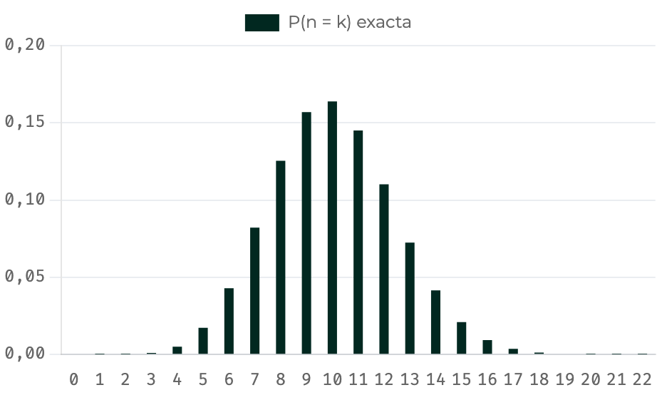

El simulador del módulo 6 en su estado inicial: la distribución exacta del tamaño de muestra con las π de los 51 estados

Ejemplo ilustrativo (dos monedas)

Con \(\pi_1 = 0{,}3\) y \(\pi_2 = 0{,}5\): \(P(n_s = 0) = 0{,}35\), \(P(n_s = 1) = 0{,}5\) y \(P(n_s = 2) = 0{,}15\).

- Dato estados: \(E(n_s) = 10\), desviación 2,41
- Dato \(P(9 \le n_s \le 11) = 0{,}466\)

Fuente: cap. 6, módulo 6, bloque «Poisson sobre statepps con varianza exacta» (las dos pestañas) y su simulador.

Capítulo 6 · Probabilidades desigualesMuestreo Estadístico · UnBosque6 / 41

El diseño de Poisson

## Con \(\pi_{kl} = \pi_k\pi_l\), la independencia da la varianza más simple

$$V(\hat{t}_\pi) = \sum_{k \in U}\left(\frac{1}{\pi_k} - 1\right) y_k^2 \qquad\qquad \widehat{V}(\hat{t}_\pi) = \sum_{k \in s} (1 - \pi_k)\,\frac{y_k^2}{\pi_k^2}$$

- Con monedas independientes, \(\pi_{kl} = \pi_k\pi_l\): de la doble suma solo queda la diagonal
- \(E(n_s) = \sum \pi_k\) y \(V(n_s) = \sum \pi_k(1 - \pi_k)\)

Fuente: cap. 6, módulo 6 (fórmula); Gutiérrez, §4.1.

Capítulo 6 · Probabilidades desigualesMuestreo Estadístico · UnBosque7 / 41

El diseño de Poisson

## Con esta semilla salieron 8 estados, y el HT quedó a menos de un error estándar

Poisson con los estados: n aleatorio y varianza exacta

```
set.seed(2026)
s_poi <- rbinom(nrow(statepps), 1, pi_st) == 1
c(n_obtenido = sum(s_poi), E_n = sum(pi_st),
  de_n = sqrt(sum(pi_st * (1 - pi_st))))
#> n_obtenido        E_n       de_n
#>   8.000000  10.000000   2.414976
c(t_HT = sum(statepps$counties[s_poi] / pi_st[s_poi]))
#>     t_HT
#> 1896.203
c(V_exacta = sum((1 - pi_st) * statepps$counties^2 / pi_st),
  ee = sqrt(sum((1 - pi_st) * statepps$counties^2 / pi_st)))
#>    V_exacta          ee
#> 1604348.622    1266.629
```

- Dato HT de 1896 condados, frente a un total de 3143
- Dato varianza exacta 1 604 349: error estándar de 1267
- `Lectura` lejos, pero dentro de lo esperable con este diseño

Fuente: cap. 6, módulo 6, bloque «Poisson sobre statepps con varianza exacta» (pestaña R, sin las dos monedas). Usa `statepps` y `pi_st`, del módulo 5.

Capítulo 6 · Probabilidades desigualesMuestreo Estadístico · UnBosque8 / 41

Pregunta para la clase

## Con \(\pi_k = n\,y_k/t\), ¿qué pasa con la varianza del HT de Poisson?

Aquí \(n = E(n_s)\) es el tamaño esperado.

1. No es cero: cada unidad aporta \(t/n\), así que el HT vale \(t\,n_s/n\) y cambia con \(n_s\)
2. Es cero, porque los cocientes \(y_k/\pi_k\) son todos iguales
3. No se puede calcular: Poisson no tiene \(\pi_{kl}\)

Respuesta

La 1. Los cocientes sí son iguales, como dice la 2, pero el HT los suma sobre la muestra, y el número de sumandos es aleatorio. La 3 falla: Poisson sí tiene \(\pi_{kl}\), las más simples, \(\pi_k\pi_l\).

Fuente: cap. 6, módulo 11, pregunta 9 de la autoevaluación.

Capítulo 6 · Probabilidades desigualesMuestreo Estadístico · UnBosque9 / 41

El diseño de Poisson

## Con \(\pi \propto y\), el HT de Poisson solo depende de cuántas unidades salen

$$\pi_k = n\,\frac{y_k}{t} \quad\Longrightarrow\quad \hat{t}_\pi = \frac{t}{n}\,n_s$$

- Dato con \(y\) = población: 10 estados aciertan; 15 se pasan un 49 %; 8 se quedan en el 80,5 %
- **Remedio**, con \(\pi \propto x\): la razón del capítulo 3, \(t_x\,\hat{t}_{y,\pi}/\hat{t}_{x,\pi}\), cancela la fracción \(n_s/n\)
- Dato counties, 20 000 muestras simuladas: el error cuadrático medio (ECM) baja de 1 574 244 a 773 791

Fuente: cap. 6, módulo 6, bloque «Poisson con pi proporcional a y, y la corrección de razón»; Gutiérrez, §4.1.3.

Capítulo 6 · Probabilidades desigualesMuestreo Estadístico · UnBosque10 / 41

El diseño de Poisson

## Poisson paga su \(n\) aleatorio: deff 3,51, y con la razón, 1,69

| Diseño, \(n = 10\) estados | Varianza | deff |
| --- | --- | --- |
| πPT sistemático, lista por población | 344 951 | 0,75 |
| MAS sin reemplazo | 456 975 | 1 |
| πPT sistemático, lista alfabética | 575 401 | 1,26 |
| πPT de Tillé, sin \(\pi_{kl}\) nulas | 697 273 | 1,53 |
| Poisson con el estimador de razón (ECM) | 773 791 | 1,69 |
| Hansen–Hurwitz, \(\psi \propto\) población | 963 006 | 2,11 |
| Poisson, el HT | 1 604 349 | 3,51 |

Total de condados. **deff:** la varianza entre la del MAS sin reemplazo. Todas exactas, salvo el ECM de la razón (20 000 muestras simuladas).

Fuente: cap. 6, módulo 6, tabla «Diez diseños para el mismo total, con el mismo n» (siete de sus diez filas).

Capítulo 6 · Probabilidades desigualesMuestreo Estadístico · UnBosque11 / 41

Universidad El Bosque

Muestreo Estadístico

Capítulo 6 · Probabilidades desiguales

El diseño de Poisson

Estimar la varianza del HT

Cuándo el HT se comporta mal

PPT en dos etapas

Importancia y active learning

Cierre del capítulo 6

02

## Estimar la varianza del HT

Estimar el total pide las \(\pi\); estimar su varianza pide además las \(\pi_{kl}\), las probabilidades de que cada par salga junto.

Leer en el material: Estimar la varianza del HT

12 / 41

Estimar la varianza del HT

## La varianza del HT se puede escribir de dos maneras

$$V(\hat{t}_\pi) = \sum_{k \in U}\sum_{l \in U} \Delta_{kl}\,\frac{y_k}{\pi_k}\,\frac{y_l}{\pi_l} \qquad \Delta_{kl} = \pi_{kl} - \pi_k\pi_l$$

$$V(\hat{t}_\pi) = \sum_{k < l} (\pi_k\pi_l - \pi_{kl})\left(\frac{y_k}{\pi_k} - \frac{y_l}{\pi_l}\right)^2$$

- La primera es la **forma HT**; la segunda, la de **Sen–Yates–Grundy** (SYG), solo para tamaño fijo
- Con tamaño fijo, \(\pi_{kl}\) suele ser menor que \(\pi_k\pi_l\): si entra \(k\), quedan menos cupos para \(l\)

Fuente: cap. 6, módulo 7 (fórmula); Gutiérrez, Resultado 4.3.1; Lohr 3.ª ed., §6.4.1.

Capítulo 6 · Probabilidades desigualesMuestreo Estadístico · UnBosque13 / 41

Estimar la varianza del HT

## Con las tiendas, los pares con D aportan casi toda la varianza

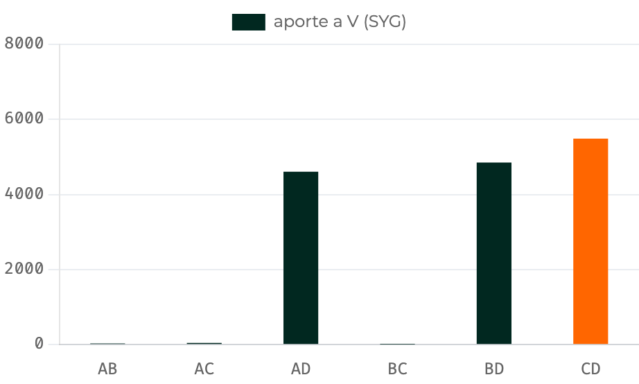

El simulador del módulo 7 en su estado inicial: el aporte de cada par de tiendas a la varianza SYG, con CD resaltado

- Dato la forma SYG reproduce la varianza exacta del diseño del módulo 4: 15 026
- `Lectura` no porque su primer factor sea grande, sino porque \(y_D/\pi_D\) queda lejos de los demás cocientes

Fuente: cap. 6, módulo 7, bloque «La matriz pi_kl del diseño pequeño y el SYG» y su simulador.

Capítulo 6 · Probabilidades desigualesMuestreo Estadístico · UnBosque14 / 41

Estimar la varianza del HT

## Estimada con una muestra, la forma HT puede salir negativa; SYG, en este diseño, no

| Muestra | AB | AC | AD | BC | BD | CD |
| --- | --- | --- | --- | --- | --- | --- |
| SYG | 523 | 564 | 20 093 | 16 | 19 414 | 20 258 |
| Forma HT | −2342 | −1241 | 22 860 | −1360 | 20 182 | 18 952 |

- Cada par de la muestra se divide entre \(\pi_{kl}\): es el HT aplicado a los pares
- Dato promediadas con \(p(s)\), las dos dan 15 026: son insesgadas
- SYG no puede salir negativa si \(\pi_k\pi_l \ge \pi_{kl}\) en todos los pares (condición de Yates–Grundy)

Fuente: cap. 6, módulo 7, bloque «Los dos estimadores de la varianza en las seis muestras».

Capítulo 6 · Probabilidades desigualesMuestreo Estadístico · UnBosque15 / 41

Estimar la varianza del HT

## agpps: con las mismas \(\pi_{kl}\), la forma HT da un error estándar seis veces mayor

survey con la matriz de conjuntas (pps = ppsmat)

```
dis_yg <- svydesign(id = ~1, fpc = ~SelectionProb, data = agpps,
                    pps = ppsmat(Pmat), variance = "YG")
svytotal(~acres92, dis_yg)
#>             total       SE
#> acres92 936291173 11715204
dis_ht <- svydesign(id = ~1, fpc = ~SelectionProb, data = agpps,
                    pps = ppsmat(Pmat), variance = "HT")
svytotal(~acres92, dis_ht)
#>             total       SE
#> acres92 936291173 70466698
```

- **Los datos:** 15 condados sorteados con \(\pi \propto\) acres de 1987, con la matriz 15 × 15 de \(\pi_{kl}\); se estiman los acres de 1992: 936 millones
- Dato error estándar con SYG: 11,7 millones de acres; con la forma HT: 70,5 millones
- Dato con la aproximación con reemplazo, sin ninguna \(\pi_{kl}\): 12,3 millones

Fuente: cap. 6, módulo 7, bloques «agpps: forma HT y forma SYG a mano» y «survey con ppsmat reproduce ambos»; Lohr 3.ª ed., ej. 6.10. Usa `agpps` y `Pmat`, de los bloques anteriores del módulo 7.

Capítulo 6 · Probabilidades desigualesMuestreo Estadístico · UnBosque16 / 41

Pregunta para la clase

## Mismos datos, mismas \(\pi_{kl}\), errores estándar de 70,5 y 11,7 millones: ¿qué pasa?

1. La forma HT está mal programada: deberían dar lo mismo
2. SYG subestima: el verdadero es el de la forma HT, que usa todos los términos
3. La forma HT suma términos de signos opuestos que casi se cancelan; SYG suma solo positivos

Respuesta

La 3. `survey` reproduce las dos cifras: no hay error de programación, son dos estimadores distintos de la misma varianza. La forma HT ni siquiera se anula cuando todos los \(y_k/\pi_k\) son iguales, y SYG sí: el ejercicio 3 lo comprueba.

Fuente: cap. 6, módulo 11, pregunta 10 de la autoevaluación.

Capítulo 6 · Probabilidades desigualesMuestreo Estadístico · UnBosque17 / 41

Estimar la varianza del HT

## Casi nunca hay \(\pi_{kl}\): se estima como si fuera con reemplazo

$$\psi_k = \frac{\pi_k}{n}, \qquad z_k = \frac{y_k}{\psi_k} = \frac{n\,y_k}{\pi_k}, \qquad \widehat{V} = \frac{s_z^2}{n}$$

- Es el Hansen–Hurwitz de la sesión 1, con \(\pi \approx n\,\psi\); las unidades forzosas quedan fuera
- **Conservadora** cuando el sorteo sin reemplazo es más eficiente, lo habitual: sobrestima, y el exceso crece con \(n/N\)
- Dato en los estados (\(n/N = 0{,}2\)), su esperanza es 1,53 veces la varianza verdadera del sistemático

Fuente: cap. 6, módulo 7 (aproximación con reemplazo); Lohr 3.ª ed., ec. 6.24.

Capítulo 6 · Probabilidades desigualesMuestreo Estadístico · UnBosque18 / 41

Estimar la varianza del HT

## Qué estimador usar depende de lo que se sepa del diseño

| Situación | Estimador de la varianza |
| --- | --- |
| Tamaño fijo y \(\pi_{kl}\) conocidas | SYG |
| Tamaño aleatorio, como Poisson | Forma HT (en Poisson, la del módulo 6) |
| \(\pi_{kl}\) desconocidas, el caso habitual | Aproximación con reemplazo |

`Lectura` Las encuestas reales casi nunca conocen sus \(\pi_{kl}\): la sección de dos etapas muestra cómo se apoyan en la aproximación con reemplazo.

Fuente: cap. 6, módulo 7 (tabla «En resumen»).

Capítulo 6 · Probabilidades desigualesMuestreo Estadístico · UnBosque19 / 41

Universidad El Bosque

Muestreo Estadístico

Capítulo 6 · Probabilidades desiguales

El diseño de Poisson

Estimar la varianza del HT

Cuándo el HT se comporta mal

PPT en dos etapas

Importancia y active learning

Cierre del capítulo 6

03

## Cuándo el HT se comporta mal

Insesgado no quiere decir útil: una unidad con un valor enorme y una \(\pi\) pequeña basta para arruinar el estimador.

Leer en el material: Cuándo el HT se comporta mal

20 / 41

Cuándo el HT se comporta mal

## Bajo Poisson, cada unidad aporta \((1/\pi_k - 1)\,y_k^2\) a la varianza

$$V(\hat{t}_\pi) = \sum_{k \in U}\left(\frac{1}{\pi_k} - 1\right) y_k^2$$

Con tamaño fijo la fórmula es otra, pero el mecanismo es el mismo.

Ejemplo ilustrativo (Basu, 1971; una sola extracción)

Un circo pesa uno de sus 50 elefantes: el mediano sale con probabilidad 99/100 y cada uno de los otros, con 1/4900. Si sale el mediano, el HT da 100/99 de su peso; si sale otro, 4900 veces el suyo.

`Lectura` Insesgado, y absurdo con cualquier muestra.

Fuente: cap. 6, módulo 8; Lohr 3.ª ed., §6.7.

Capítulo 6 · Probabilidades desigualesMuestreo Estadístico · UnBosque21 / 41

Cuándo el HT se comporta mal

## Veinte negocios y un elefante con el área mínima y el 82 % de las ventas

Ejemplo ilustrativo (población simulada en el bloque del módulo 8)

20 negocios con ventas proporcionales al área, salvo uno: el «elefante», con el área mínima (empatada con otros dos) y 8790 de las 10 726 ventas. Con \(\pi \propto\) área y \(n = 5\), le toca \(\pi = 0{,}0649\).

- Dato el 93,5 % de las veces no sale, y el HT ve, más o menos, el resto: 1936
- Dato cuando sale, su término \(y/\pi\) vale 135 366, más de doce veces el total
- `Lectura` en promedio da el total, pero casi nunca se acerca a él

Fuente: cap. 6, módulo 8, bloque «La curva de la varianza explosiva» (semilla 2026).

Capítulo 6 · Probabilidades desigualesMuestreo Estadístico · UnBosque22 / 41

Pregunta para la clase

## El elefante pone el 99,95 % de la varianza: ¿por qué?

1. Porque su \(y\) es el 82 % del total: cualquier diseño sufriría igual
2. Por la combinación de \(y\) grande y \(\pi\) pequeña
3. Porque su \(\pi\) es pequeña: con cualquier \(y\), daría el mismo aporte

Respuesta

La 2. Con \(\pi = 1\) su aporte sería cero, porque \(1/\pi - 1\) se anula: no es solo su \(y\) (la 1). Con un \(y\) pequeño, sería pequeño aunque \(\pi\) lo fuera: no es solo su \(\pi\) (la 3). Y la \(\pi\) la elige el diseñador.

Fuente: cap. 6, módulo 11, pregunta 11 de la autoevaluación.

Capítulo 6 · Probabilidades desigualesMuestreo Estadístico · UnBosque23 / 41

Cuándo el HT se comporta mal

## Subir la \(\pi\) del elefante hunde la varianza; con \(\pi = 1\), su término vale cero

[figure not shown]

La varianza del HT bajo Poisson según la π del elefante, con tres puntos marcados uno a uno

- Dato bajar su \(\pi\) a 0,005 multiplica la varianza por 13,8
- Dato con \(\pi = 0{,}5\), la varianza es unas 200 veces menor que con 0,005
- `Lectura` con \(\pi = 1\), su término desaparece: la \(\pi\) la elige el diseñador

Fuente: cap. 6, módulo 8, bloque «La curva de la varianza explosiva» y simulador «El elefante y su π».

Capítulo 6 · Probabilidades desigualesMuestreo Estadístico · UnBosque24 / 41

Cuándo el HT se comporta mal

## El elefante se evita antes, al diseñar, al estimar o después

Opinión del material · cuatro defensas, según el momento

1Antes de muestreartamaños al día: el elefante suele nacer de una medida desactualizada

→

2Al diseñarinclusión forzosa: \(\pi_k = 1\) ante la sospecha

→

3Al estimarla razón (capítulo 3), si hay una auxiliar que sí acompañe a \(y\)

→

4Despuésrecortar el peso, a cambio de un pequeño sesgo (capítulo 7)

Fuente: cap. 6, módulo 8 (advertencia «Cuatro defensas, según el momento»); Lohr 3.ª ed., §6.7.

Capítulo 6 · Probabilidades desigualesMuestreo Estadístico · UnBosque25 / 41

Idea clave · opinión del material

## Borrar la observación rara no es una defensa contra el elefante

La unidad es legítima: el problema fue el diseño que le dio una \(\pi\) pequeña.

Capítulo 6 · Probabilidades desigualesMuestreo Estadístico · UnBosque26 / 41

Universidad El Bosque

Muestreo Estadístico

Capítulo 6 · Probabilidades desiguales

El diseño de Poisson

Estimar la varianza del HT

Cuándo el HT se comporta mal

PPT en dos etapas

Importancia y active learning

Cierre del capítulo 6

04

## PPT en dos etapas

Clases grandes con más probabilidad de salir y el mismo número de estudiantes en cada una: todos acaban con el mismo peso.

Leer en el material: PPT en dos etapas

27 / 41

PPT en dos etapas

## classes: 5 de 15 clases con PPT y 4 estudiantes en cada una

- **El marco:** `classes`, 15 clases de estadística; la clase \(i\) tiene \(M_i\) estudiantes, y \(K = 647\) en total. \(M_i\) es la medida de tamaño (la \(x_k\) de antes) y \(K\) su total (la \(t_x\))
- **Etapa 1:** \(n = 5\) clases sin reemplazo, con \(\pi_i = 5\,M_i/K\)
- **Etapa 2:** \(m = 4\) estudiantes en cada clase sorteada, con probabilidad \(4/M_i\)
- **La muestra:** `classpps`, con las horas que cada estudiante dedica a estadística

Fuente: cap. 6, módulo 9; classes.csv y classpps.csv; Lohr 3.ª ed., Tabla 6.2 (el marco, ej. 6.2) y ej. 6.11 (la muestra).

Capítulo 6 · Probabilidades desigualesMuestreo Estadístico · UnBosque28 / 41

Pregunta para la clase

## ¿Qué peso tiene un estudiante de la clase de 100? ¿Y de la de 22?

Su probabilidad es la de su clase por la suya dentro de ella; el peso es el inverso.

Respuesta

Los dos, \(647/20 = 32{,}35\): \(\dfrac{5 \cdot 100}{647}\cdot\dfrac{4}{100} = \dfrac{5 \cdot 22}{647}\cdot\dfrac{4}{22} = \dfrac{20}{647} = 0{,}0309\). El \(M_i\) se cancela.

Fuente: cap. 6, módulo 9 (la probabilidad de cada estudiante); las clases 14 (M = 100) y 4 (M = 22) están en classpps.

Capítulo 6 · Probabilidades desigualesMuestreo Estadístico · UnBosque29 / 41

PPT en dos etapas

## Con PPT y \(m\) fijo, todos los estudiantes pesan lo mismo

[figure not shown]

El peso final de un estudiante de cada clase del marco: primero con probabilidades iguales, después con PPT

- Dato con probabilidades iguales, un estudiante de la clase de 100 pesa 6,7 veces uno de la de 15
- Dato con PPT y \(m = 4\): 32,35 en las 15 clases

Diseño autoponderado

Todas las unidades observadas tienen el mismo peso: \(w = \dfrac{K}{nM_i}\cdot\dfrac{M_i}{m} = \dfrac{K}{nm}\).

Fuente: cap. 6, módulo 9 (definición y simulador «La cancelación, en vivo»); classes.csv.

Capítulo 6 · Probabilidades desigualesMuestreo Estadístico · UnBosque30 / 41

PPT en dos etapas

## Cada clase estima el total, y la varianza sale de su dispersión

HH de dos etapas y su versión con survey

```
z <- por_clase$t_hat / por_clase$psi
round(z, 1)
#> [1] 2264.5 3235.0 2345.4 2021.9 1294.0
c(t_HH = mean(z), ee = sqrt(var(z) / 5))
#>      t_HH        ee
#> 2232.1500  311.7624
dis_cl <- svydesign(id = ~class, weights = ~finalweight,
                    data = classpps)
svytotal(~hours, dis_cl)
#>        total     SE
#> hours 2232.2 311.76
unique(classpps$finalweight)
#> [1] 32.35
```

- \(z_i = \hat{t}_i/\psi_i = 647\,\bar{y}_i\), con \(\psi_i = \pi_i/5 = M_i/647\)
- Dato clase 14: \(M = 100\), \(\bar{y} = 2{,}0\) horas, \(z = 1294\)
- Dato total de horas 2232,15, con error estándar (ee) de 311,8

Fuente: cap. 6, módulo 9, bloques «HH de dos etapas a mano» y «survey y el diseño autoponderado» (recortados); Lohr 3.ª ed., ec. 6.30. Usa `por_clase`, del primer bloque del módulo, y `classpps`.

Capítulo 6 · Probabilidades desigualesMuestreo Estadístico · UnBosque31 / 41

PPT en dos etapas

## Muchas encuestas grandes en persona sortean sus unidades primarias con PPT

- Las **UPM**, unidades primarias de muestreo, son las que se sortean primero: aquí, las clases
- Lohr, ej. 6.12: la encuesta de seroprevalencia de COVID-19 en España sorteó secciones censales con PPT y 24 hogares en cada una
- `Lectura` dentro de cada estrato, muestra casi autoponderada, y la misma carga de trabajo, conocida de antemano, en cada sección
- Gutiérrez da el mismo motivo: fijar las entrevistas por UPM controla el trabajo de campo

Fuente: cap. 6, módulo 9; Lohr 3.ª ed., ej. 6.12; Gutiérrez, §7.3.1.

Capítulo 6 · Probabilidades desigualesMuestreo Estadístico · UnBosque32 / 41

Universidad El Bosque

Muestreo Estadístico

Capítulo 6 · Probabilidades desiguales

El diseño de Poisson

Estimar la varianza del HT

Cuándo el HT se comporta mal

PPT en dos etapas

Importancia y active learning

Cierre del capítulo 6

05

## Importancia y active learning

El Hansen–Hurwitz de la sesión 1 se usa fuera de las encuestas con otro nombre: muestreo por importancia.

Leer en el material: Importancia y active learning

33 / 41

Importancia y active learning

## El PPT con reemplazo es el muestreo por importancia

| Encuestas (este capítulo) | Muestreo por importancia |
| --- | --- |
| unidad \(i\) del marco | punto \(u_i\) donde se evalúa la función |
| valor \(y_i\) | \(f(u_i)\) |
| probabilidad de extracción \(\psi_i\) | la «propuesta» |
| peso \(1/(n\,\psi_i)\) | peso de importancia |
| Hansen–Hurwitz, \(\dfrac{1}{n}\sum y_i/\psi_i\) | estimador por importancia |

`Lectura` La propuesta ideal, \(\psi_i = y_i/t\), da varianza cero, pero exige conocer \(y\).

Dato Con los estados, para el total de condados, la propuesta \(\psi \propto\) población da 963 006, y la uniforme, 557 287: lo que anticipaba Raj.

Fuente: cap. 6, módulo 10 (tabla de traducción y bloque «Tres propuestas y sus varianzas exactas»).

Capítulo 6 · Probabilidades desigualesMuestreo Estadístico · UnBosque34 / 41

Importancia y active learning

## BigLucy: mezclar la propuesta con algo de uniforme le gana a la propuesta sola

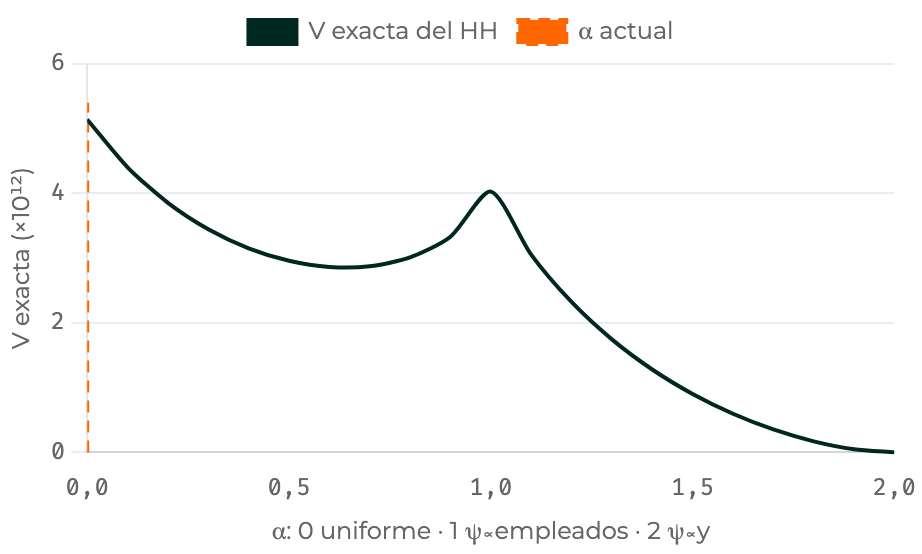

El simulador del módulo 10 en su estado inicial: la varianza exacta del HH según la mezcla α

- **Los datos:** 85 296 empresas ficticias; se estima el ingreso con 100 extracciones
- \(\alpha\) mezcla las propuestas: 0, uniforme; 1, \(\psi \propto\) empleados; 2, \(\psi \propto\) ingreso
- Dato \(\alpha = 0{,}6\): 1,8 veces menos varianza que la uniforme; \(\alpha = 1\): 1,3 veces
- `Lectura` la recta del ingreso sobre los empleados corta el eje en 99,9, el 23 % de su media

Fuente: cap. 6, módulo 10 (simulador «El camino hacia la propuesta perfecta»); BigLucy (`TeachingSampling`), que Gutiérrez, §4.2.4, usa con el ingreso como tamaño.

Capítulo 6 · Probabilidades desigualesMuestreo Estadístico · UnBosque35 / 41

Importancia y active learning

## Active learning: con pesos \(1/\psi\), la tasa de error sale insesgada

Ejemplo ilustrativo (datos simulados en el bloque del módulo 10)

Un modelo clasifica 10 000 imágenes y hay presupuesto para etiquetar 100, sorteadas con \(\psi\) proporcional a la duda del modelo, mezclada con un 10 % de uniforme. Tasa de error verdadera: 0,162.

| 2000 repeticiones | Promedio | Desviación |
| --- | --- | --- |
| sin pesos | 0,288 | 0,046 |
| con pesos \(1/\psi\) (HH) | 0,162 | 0,033 |
| MAS con reemplazo | 0,162 | 0,036 |

Fuente: cap. 6, módulo 10, bloque «Active learning: la tasa de error con y sin pesos» (semilla 2026).

Capítulo 6 · Probabilidades desigualesMuestreo Estadístico · UnBosque36 / 41

Pregunta para la clase · varias respuestas

## Sobre muestreo por importancia, ¿qué es cierto?

1. La propuesta \(\psi \propto y\) tiene varianza cero, pero exige conocer \(y\)
2. Si los datos se recogieron sin registrar las \(\psi\), basta ponderar después
3. Una propuesta con correlación 0,46 con \(y\) puede ser peor que la uniforme
4. Con cualquier \(\psi\) conocida y positiva, el estimador es insesgado

Respuesta

Todas menos la 2: una \(\psi\) que nadie anotó no se puede invertir. La 1, la 3 y la 4 son el resumen de la sección.

Fuente: cap. 6, módulo 11, pregunta 13 de la autoevaluación.

Capítulo 6 · Probabilidades desigualesMuestreo Estadístico · UnBosque37 / 41

Idea clave · advertencia del material

## La condición que no se negocia: \(\psi\) conocida y positiva

Una unidad con \(\psi = 0\) no entra en ninguna estimación, y un conjunto de datos recogido «según llegaba» no tiene \(\psi\) conocida: ninguna ponderación posterior lo arregla del todo.

Capítulo 6 · Probabilidades desigualesMuestreo Estadístico · UnBosque38 / 41

Universidad El Bosque

Muestreo Estadístico

Capítulo 6 · Probabilidades desiguales

El diseño de Poisson

Estimar la varianza del HT

Cuándo el HT se comporta mal

PPT en dos etapas

Importancia y active learning

Cierre del capítulo 6

06

## Cierre del capítulo 6

Leer en el material: Autoevaluación y ejercicios guiados

39 / 41

Cierre del capítulo 6

## Lo que te llevas del capítulo

- Poisson regala la varianza más simple, a cambio de un \(n\) aleatorio que la razón corrige
- La varianza del HT pide \(\pi_{kl}\); sin ellas, la aproximación **con reemplazo**, conservadora
- El elefante es \(y\) grande con \(\pi\) pequeña: se evita **al diseñar**, no borrando datos
- PPT arriba y \(m\) fijo abajo: diseño **autoponderado**, el de las encuestas de hogares
- En ciencia de datos, pesos \(1/\psi\) con \(\psi\) **conocida y positiva**

Javier Mauricio Sierra

Capítulo 6 · Probabilidades desigualesMuestreo Estadístico · UnBosque40 / 41

Cierre del capítulo 6

## Para la próxima semana

1Autoevaluaciónrehaz sin mirar las seis últimas; la 8 no se vio en clase

→

2Ejercicio guiado 3SYG con agpps y acres87: ¿por qué sale casi cero?

→

3Ejercicio guiado 4Poisson frente al sistemático, con counties y waterarea

→

4Ejercicios 5 y 6Gutiérrez §4.5, a mano y con el código que lo comprueba

→

5Hacia el capítulo 7estratos, UPM con PPT, submuestreo y pesos ajustados, todo a la vez

Fuente: cap. 6, módulo 11 (autoevaluación, ejercicios guiados y «Hacia el capítulo 7»).

Capítulo 6 · Probabilidades desigualesMuestreo Estadístico · UnBosque41 / 41

### Atajos del teclado

[output not shown]

·

00:00

A continuación

Notas